# Practical 3

Matteo Larrode

2024-01-21

```r
library(igraph)
library(tidyverse)
```

### Exercice 1

**a)**

This network is a weighted undirected network.

**b)**

```r
got <- read.csv("data/stormofswords.csv")
summary(got)
```

```
##     Source             Target              Weight
##  Length:352         Length:352         Min.   : 4.00
##  Class :character   Class :character   1st Qu.: 5.00
##  Mode  :character   Mode  :character   Median : 7.00
##                                        Mean   :12.28
##                                        3rd Qu.:14.00
##                                        Max.   :96.00
```

Number of edges:

```r
nrow(got)
```

```
## [1] 352
```

Unique source characters:

```r
unique(got$Source)
```

```
##  [1] "Aemon"        "Aerys"        "Alliser"      "Amory"        "Arya"
##  [6] "Balon"        "Belwas"       "Beric"        "Bran"         "Brienne"
## [11] "Bronn"        "Brynden"      "Catelyn"      "Cersei"       "Craster"
## [16] "Daario"       "Daenerys"     "Davos"        "Eddard"       "Eddison"
## [21] "Edmure"       "Gendry"       "Gilly"        "Gregor"       "Hodor"
## [26] "Hoster"       "Irri"         "Jaime"        "Janos"        "Joffrey"
## [31] "Jojen"        "Jon"          "Jon Arryn"    "Jorah"        "Kevan"
## [36] "Loras"        "Lothar"       "Luwin"        "Lysa"         "Mance"
## [41] "Meera"        "Melisandre"   "Meryn"        "Missandei"    "Myrcella"
## [46] "Oberyn"       "Podrick"      "Rattleshirt"  "Renly"        "Rhaegar"
## [51] "Rickard"      "Rickon"       "Robb"         "Robert"       "Robert Arryn"
## [56] "Roose"        "Samwell"      "Sandor"       "Sansa"        "Shae"
## [61] "Shireen"      "Stannis"      "Tommen"       "Tyrion"       "Tywin"
## [66] "Val"          "Varys"        "Viserys"      "Walder"       "Walton"
## [71] "Ygritte"
```

**c) & d)**

```r
got_net <- graph.data.frame(got, directed = FALSE)
got_net <- set_edge_attr(got_net, "weight", value= E(got_net)$Weight)

summary(got_net)
```

```
## IGRAPH 4e93fdd UNW- 107 352 --
## + attr: name (v/c), Weight (e/n), weight (e/n)
```

**e)**

[figure not shown]

```r
plot.igraph(got_net)
```

This is a bit messy, we can remove nodes remove smaller nodes (nodes that have smaller than a given degree) with `g <- delete.vertices(g,which(degree(g)<1))` or faint edges (edges with low weights) from the graph with `g <- delete.edges(g, which(E(g)$weight <=7))`. We will do the former

[figure not shown]

```r
got_net_reduced <- delete.vertices(got_net, which(degree(got_net) < 3))

plot.igraph(got_net_reduced)
```

Let’s try to improve the plot. We can: - adjust edge width proportional to the weight of the edge - vertex size proportional to page rank - vertex label proportional to the betweenness of the node - remove the margins, and set aspect size to zero:

[figure not shown]

```r
plot.igraph(got_net,
            edge.color="black", edge.width=E(got_net)$Weight/10,
            vertex.size = page.rank(got_net)$vector*250,
            vertex.label.cex=betweenness(got_net)/600,
            margin=c(0,0,0,0) , asp=0)
```

**f)**

```r
sort(degree(got_net), decreasing = T)[1:15]
```

```
##   Tyrion      Jon    Sansa     Robb    Jaime    Tywin   Cersei     Arya
##       36       26       26       25       24       22       20       19
##  Catelyn  Joffrey   Robert  Samwell     Bran Daenerys  Stannis
##       18       18       18       15       14       14       14
```

```r
sort(strength(got_net), decreasing = T)[1:15]
```

```
##   Tyrion      Jon    Sansa    Jaime     Bran     Robb  Samwell     Arya
##      551      442      383      372      344      342      282      269
##  Joffrey Daenerys   Cersei    Tywin  Catelyn    Hodor    Mance
##      255      232      226      204      184      177      160
```

```r
sort(eigen_centrality(got_net)$vector, decreasing = T)[1:15]
```

```
##    Tyrion     Sansa     Jaime   Joffrey    Cersei      Robb     Tywin      Bran
## 1.0000000 0.8123933 0.6452363 0.6431668 0.5711504 0.4384176 0.4073000 0.3398198
##      Arya   Brienne   Catelyn  Margaery    Gregor     Hodor     Petyr
## 0.3371413 0.3318956 0.2764442 0.2749995 0.2242744 0.2214855 0.2204193
```

```r
sort(page.rank(got_net)$vector, decreasing = T)[1:15]
```

```
##     Tyrion        Jon   Daenerys      Jaime      Sansa       Robb       Bran
## 0.05545694 0.04485534 0.04103413 0.03661029 0.03636882 0.03413913 0.02902279
##    Samwell       Arya    Joffrey     Cersei      Tywin    Catelyn      Mance
## 0.02827751 0.02554165 0.02424097 0.02152907 0.02108113 0.01865992 0.01714377
##    Stannis
## 0.01681851
```

```r
sort(closeness(got_net), decreasing = T)[1:15]
```

```
##       Tyrion       Robert      Stannis         Arya        Sansa      Catelyn
## 0.0006662225 0.0006583278 0.0006435006 0.0006414368 0.0006329114 0.0006207325
##        Renly        Balon          Jon       Sandor       Cersei     Myrcella
## 0.0006075334 0.0006053269 0.0006020470 0.0006016847 0.0006009615 0.0005861665
##        Jaime        Tywin       Eddard
## 0.0005757052 0.0005727377 0.0005701254
```

```r
sort(betweenness(got_net, weights = NULL), decreasing = T)[1:15]
```

```
##    Robert    Tyrion       Jon   Stannis     Sansa   Catelyn  Daenerys     Janos
## 1166.1500 1163.7833  921.6000  696.5167  683.5667  598.0000  547.1667  506.6667
##     Tywin      Arya     Jaime   Rhaegar    Cersei     Mance     Davos
##  488.7333  449.1333  443.6500  377.8333  349.2500  318.0667  312.0000
```

```r
sort(betweenness(got_net), decreasing = T)[1:15]
```

```
##    Robert    Tyrion       Jon   Stannis     Sansa   Catelyn  Daenerys     Janos
## 1166.1500 1163.7833  921.6000  696.5167  683.5667  598.0000  547.1667  506.6667
##     Tywin      Arya     Jaime   Rhaegar    Cersei     Mance     Davos
##  488.7333  449.1333  443.6500  377.8333  349.2500  318.0667  312.0000
```

Let’s reproduce the graph from the original paper:

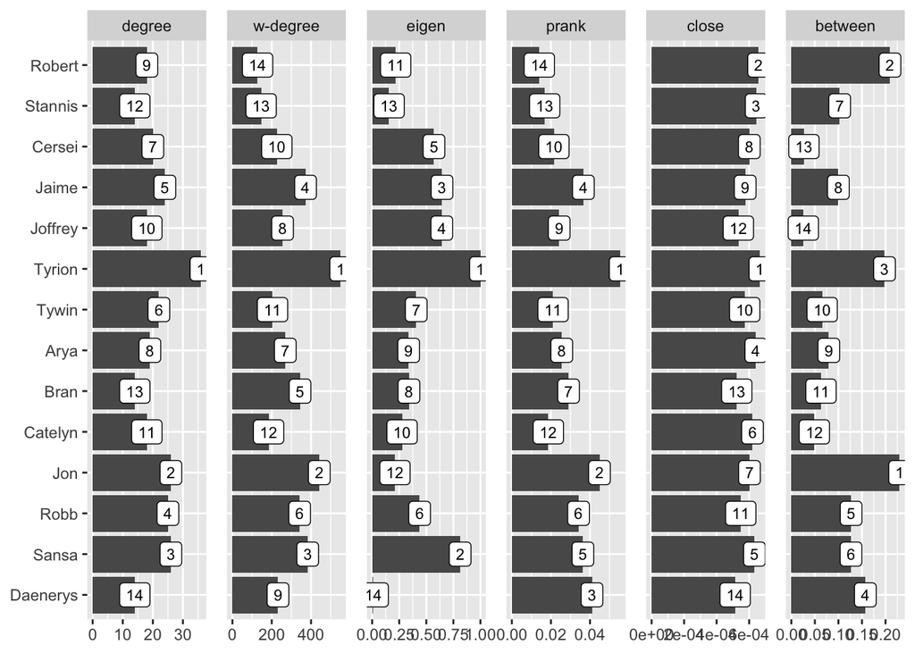

```r
C <- tibble(
  names(V(got_net)),
  degree(got_net),
  strength(got_net),
  eigen_centrality(got_net)$vector,
  eigen_centrality(got_net, weights = NA)$vector,
  page.rank(got_net)$vector,
  page.rank(got_net, weights = NA)$vector,
  closeness(got_net),
  closeness(got_net, weights = NA),
  betweenness(got_net, normalize = TRUE, weights = NA),
  betweenness(got_net, weights = NA)
  )

names(C) <- c(
  "cname", "degree", "w-degree",
  "eigen", "unw-eigen", "prank",
  "unw-prank", "close", "unw-close",
  "between", "unw-between")

toselect <- c(
  "Robert", "Stannis", "Cersei",
  "Jaime", "Joffrey", "Tyrion",
  "Tywin", "Arya", "Bran",
  "Catelyn", "Jon", "Robb",
  "Sansa", "Daenerys")

C_sub <- C |>
  filter(cname %in% toselect) |> #select only characters in Beveridge and Shan
  arrange(match(cname, toselect)) |> #ordering by name
  select("cname", "degree", "w-degree", "eigen", "prank", "close", "between") |>
  pivot_longer(-cname, names_to = "centrality", values_to = "value") |>
  group_by(centrality) |>
  arrange(desc(value)) |>
  mutate(order = row_number()) |>
  ungroup() |>
  mutate(cname = factor(cname, levels = toselect)) |>  #arranging cname/centrality as factor for order in plot
  mutate(centrality = factor(centrality, levels = c("degree", "w-degree", "eigen", "prank", "close", "between")))

C_sub |>
  ggplot(aes(cname, value)) + geom_bar(stat ="identity") +
  facet_grid(~ centrality, scales = "free", shrink = TRUE) +
  coord_flip() + geom_label(aes(label = order), size = 3) +
  scale_x_discrete(limits = rev(levels(C_sub$cname))) +theme(
  plot.title = element_blank(),
  axis.title.x = element_blank(),
  axis.title.y = element_blank(), panel.spacing.x = unit(4, "mm"))
```

### Exercice 2

**a)**

```r
N2 <- read.csv("data/net_anon24.csv",  header = TRUE)

gn2 <- graph.data.frame(N2, directed = TRUE) +
  vertices(25, 16, 34, 64, 99, 54, 113)  #reading the edge list and adding isolates with vertices

set.seed(1)
lf2 <-layout.fruchterman.reingold(gn2) #fixing the layout with layout.fruchterman.reingold()
```

Let’s plot the network:

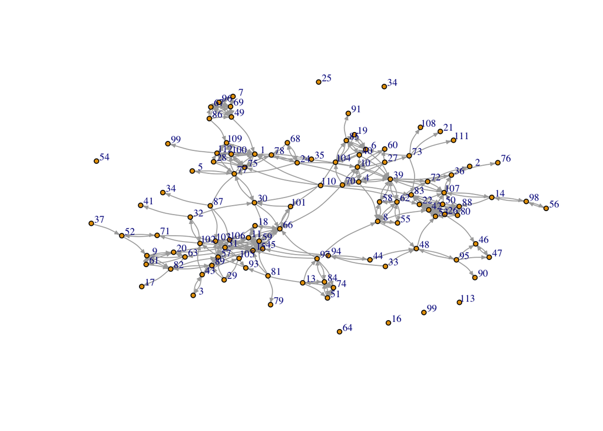

```r
plot(gn2,
     vertex.size= 2,
     edge.arrow.size = 0.3,
     vertex.label.cex = 0.7,
     vertex.label.dist=0.7,
     edge.curved=.2,
     asp = 0,
     layout = lf2)
```

Let’s calculate density: only about 3% of all possible ties are present in the network

```r
edge_density(gn2)
```

```
## [1] 0.02777314
```

For the diameter, calculations become more complicated because of the isolates. Diameter measures the longest shortest path. When there are isolates, the shortest path from those isolates to the ones connected in the larger network is undefined (infinite). To solve this, if the `unconnected` option of the `diameter()` function is set to TRUE, then R will calculate the diameter of the connected component only.

A second issue is the direction: Do we want to take into account the direction in calculating the distance between two individuals? It depends on the question. For example, if we are interested in how fast information diffuses in the network, then perhaps the direction may not matter because I can hear something from another person even if I nominated that person or that person nominated me.

```r
diameter(gn2, unconnected = TRUE, directed = FALSE)
```

```
## [1] 11
```

Ignoring the direction, the longest shortest distance between any two pairs in the connected component of our network is 11.

**b)**

```r
c2 <- read.csv("data/courses24.csv")

# extract the unique student ids of those that appear in our network
ids2 <- as.numeric((V(gn2)$name))

# subset and order "c2" using only the ids included in the vector "names"
c2 <- (c2[ids2,])

# use the set_vertex_attr() function to add information about the course
gn2 <- set_vertex_attr(gn2, "course", value = c2$course)
```

The network is now ready to plot:

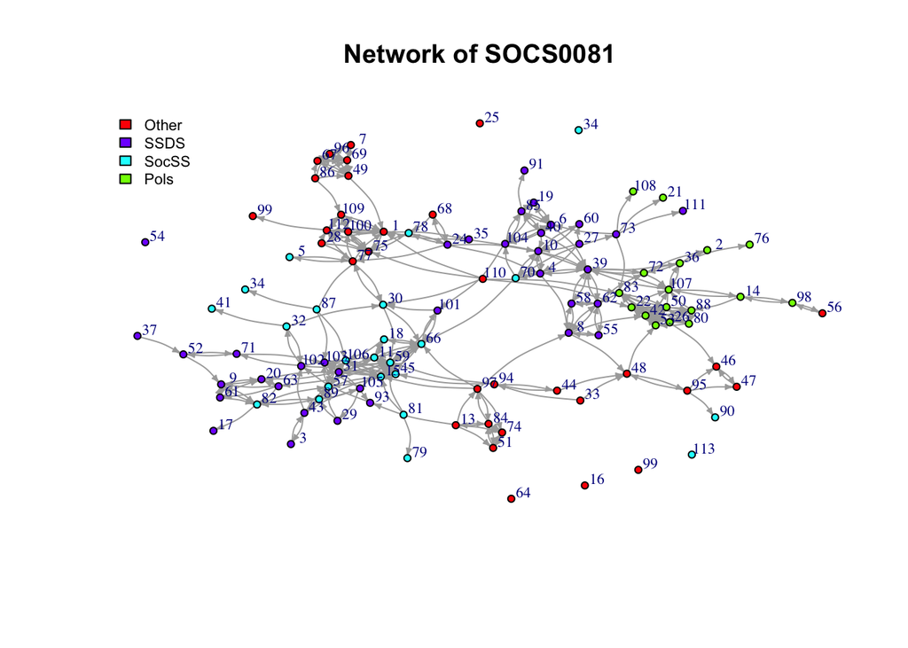

```r
plot(gn2, vertex.size= 2, edge.arrow.size = 0.3,  vertex.label.cex = 0.7,
     edge.curved=.2, asp = 0, layout = lf2, vertex.label.dist=0.7,
     vertex.color = rainbow(4)[as.factor(V(gn2)$course)], main = "Network of SOCS0081")

legend("topleft",bty = "n",legend=unique(as.factor(V(gn2)$course)), cex = 0.7,
       fill = rainbow(4)[unique(as.factor(V(gn2)$course))])
```

**c)**

We now create a new object which includes the top 3 individuals with the highest scores in multiple measures of centrality: - indegree - betweenness (we take into account the direction in betweenness which is the default option in R) - closeness (not very informative in this network because of the existence of isolated disconnected nodes (they will make everyone rather distant)) - page rank

Outdegree is not informative because the questionnaire set up a maximum of 5.

```r
cen <- cbind(names(sort(degree(gn2, mode = "in"), decreasing = TRUE)[1:3]),
              names(sort(closeness(gn2, mode = "all"), decreasing = TRUE)[1:3]),
              names(sort(betweenness(gn2), decreasing = TRUE)[1:3]),
              names((sort(page.rank(gn2)$vector, decreasing = TRUE)[1:3]))
              )
rownames(cen) <- c("top", "second", "third")
colnames(cen) <- c("indegree", "closeness", "betweenness", "google-pr")

cen
```

```
##        indegree closeness betweenness google-pr
## top    "39"     "30"      "39"        "11"
## second "59"     "66"      "77"        "106"
## third  "42"     "59"      "4"         "46"
```

Person 39 and 59 seem like rather central individuals: they appear in the top 3 list according to two measures. - 59, who is a SocSS student has a high indegree and connects SocSS students with others. - 39 is a SSDS student who functions like 59, connecting SSDS with mainly Pols folks. - 77 is an interesting case, which works as a bridge between students from “other” programmes and rest.

Now we can calculate average betweenness and indegree centrality scores across courses using the `aggregate()` function.

```r
mind <- aggregate(
  x = degree(gn2, mode = "in"),
  by = list(as.factor(V(gn2)$course)),
  FUN=mean)

mind
```

```
##   Group.1        x
## 1   Other 2.606061
## 2    Pols 3.764706
## 3   SocSS 3.434783
## 4    SSDS 2.810811
```

```r
mbe <- aggregate(
  x = betweenness(gn2),
  by = list(as.factor(V(gn2)$course)),
  FUN=mean)

mbe
```

```
##   Group.1        x
## 1   Other 211.9096
## 2    Pols 232.1862
## 3   SocSS 489.8105
## 4    SSDS 436.3021
```

PLotting the two means:

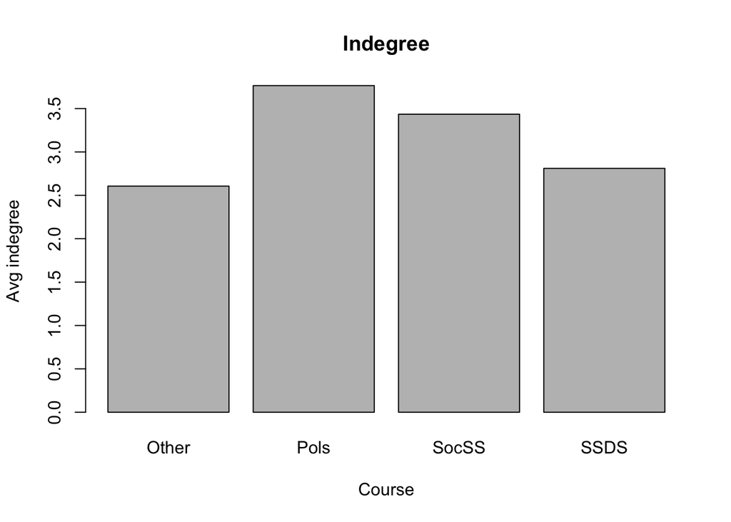

```r
barplot(
  height  = mind[,2],
  names.arg = mind[,1],
  xlab="Course",
  ylab="Avg indegree",
  main = "Indegree")
```

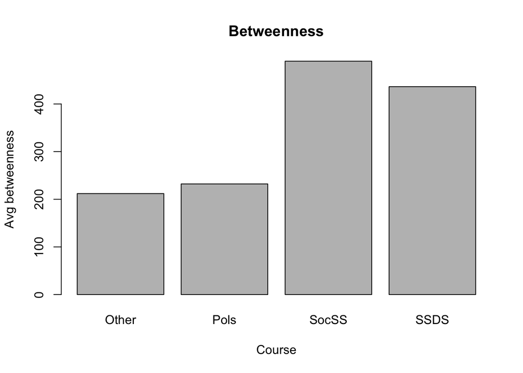

```r
barplot(
  height  = mbe[,2],
  names.arg = mbe[,1],
  xlab="Course",
  ylab="Avg betweenness",
  main = "Betweenness")
```

Politics and SocSS students have highest average indegree. While SSDS is the largest group, politics folks tend to know each other very much, hence obtain a high indegree.

SocSS students, have very high betweenness, acting as a bridge between different groups such as Politics and SSDS.

Let’s plot the network with node size proportional to centrality:

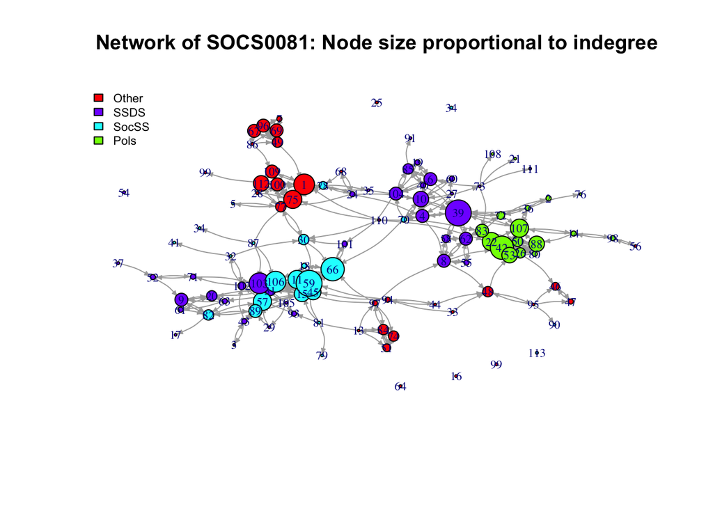

```r
plot(gn2,
     vertex.size= degree(gn2, mode = "in"),
     edge.arrow.size = 0.3,
     vertex.label.cex = 0.7,
     vertex.label.dist=0,
     edge.curved=.2,
     asp = 0, layout = lf2,
     vertex.color = rainbow(4)[as.factor(V(gn2)$course)],
     main = "Network of SOCS0081: Node size proportional to indegree")

legend("topleft",bty = "n",legend=unique(as.factor(V(gn2)$course)), cex = 0.7,
       fill = rainbow(4)[unique(as.factor(V(gn2)$course))])
```

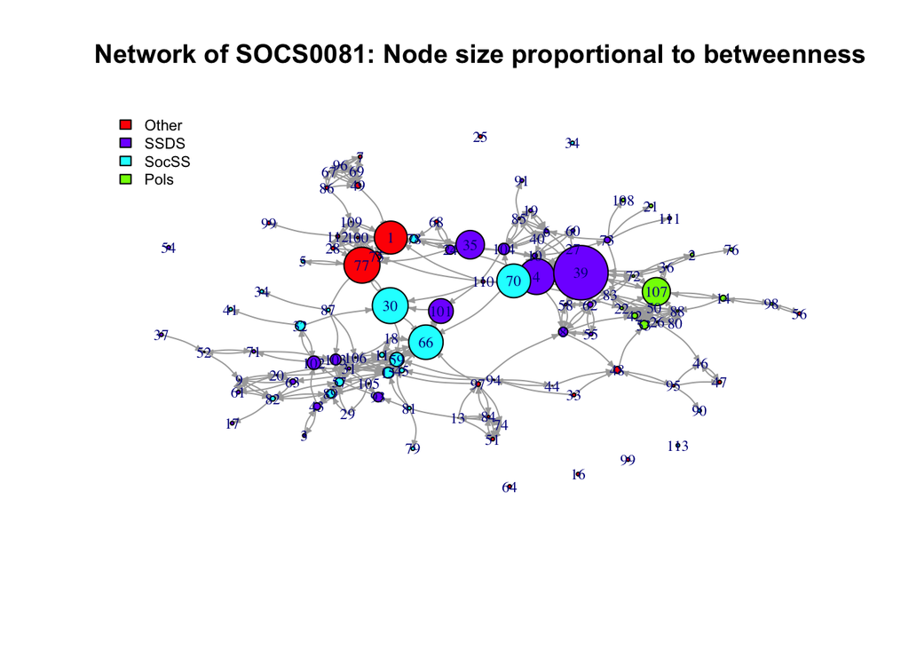

```r
plot(gn2,
     vertex.size= betweenness(gn2)/200,
     edge.arrow.size = 0.3,
     vertex.label.cex = 0.7,
     vertex.label.dist=0,
     edge.curved=.2, asp = 0, layout = lf2,
     vertex.color = rainbow(4)[as.factor(V(gn2)$course)],
     main = "Network of SOCS0081: Node size proportional to betweenness")

legend("topleft",bty = "n",legend=unique(as.factor(V(gn2)$course)), cex = 0.7,
       fill = rainbow(4)[unique(as.factor(V(gn2)$course))])
```